# Mousaw - AppliedMLFinal

### K-Nearest Neighbors

Knn could be a good fit for this data because it is possible that bots have similar characteristics as other bots and same for humans. These possible feature similarities could result in distinguishable clusters. If this is the case, knn would be an effective classifier due to clustering of users. Knn only has 1 hyperparameter, which is the value for k, or the number of neighbors. A reason not to chose knn for this dataset would be that there are many features, and knn can struggle with high dimensionality.

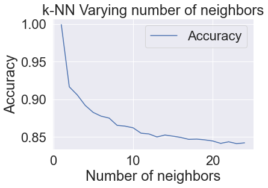

```python
neighbors = np.arange(1,25)
accuracy = np.empty(len(neighbors))

for i,k in enumerate(neighbors):
    #Setup a knn classifier with k neighbors
    knn = KNeighborsClassifier(n_neighbors=k)

    #Fit the model
    knn.fit(user_features, user_labels)

    #Compute accuracy
    accuracy[i] = knn.score(user_features, user_labels)

#Generate plot
plt.title('k-NN Varying number of neighbors')
plt.plot(neighbors, accuracy, label='Accuracy')
plt.legend()
plt.xlabel('Number of neighbors')
plt.ylabel('Accuracy')
plt.show()
```

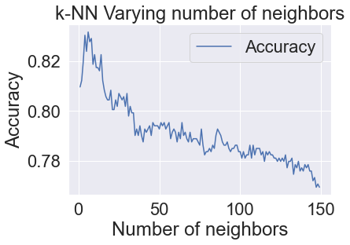

```python
#Using a grid search on actual test data, let's find best k value

#Setup arrays to store training and test accuracies
neighbors = np.arange(1,150)
accuracy = np.empty(len(neighbors))

for i,k in enumerate(neighbors):
    #Setup a knn classifier with k neighbors
    knn = KNeighborsClassifier(n_neighbors=k)

    #Fit the model
    knn.fit(user_X_train, user_Y_train)

    #Compute accuracy
    user_Y_pred = knn.predict(user_X_test)
    accuracy[i] = metrics.accuracy_score(user_Y_test,user_Y_pred)


#Generate plot
plt.title('k-NN Varying number of neighbors')
plt.plot(neighbors, accuracy, label='Accuracy')
plt.legend()
plt.xlabel('Number of neighbors')
plt.ylabel('Accuracy')
plt.show()
```

```python
knn = KNeighborsClassifier(n_neighbors=4)
knn.fit(user_X_train, user_Y_train)
print("Train accuracy "+str(knn.score(user_X_train, user_Y_train)))
print("Test accuracy "+str(knn.score(user_X_test, user_Y_test)))
```

```
Train accuracy 0.8888888888888888
Test accuracy 0.8303108808290155
```

```
              precision    recall  f1-score   support

           0       0.91      0.62      0.74       408
           1       0.69      0.93      0.79       364

    accuracy                           0.77       772
   macro avg       0.80      0.78      0.77       772
weighted avg       0.81      0.77      0.77       772
```

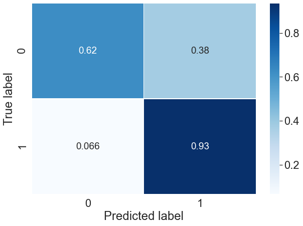

```python
print(classification_report(user_Y_test, user_Y_pred))

matrix = confusion_matrix(user_Y_test, user_Y_pred)
matrix = matrix.astype('float') / matrix.sum(axis=1)[:, np.newaxis]

plt.figure(figsize=(10,7))
sb.set(font_scale=2)
sb.heatmap(matrix, annot=True, annot_kws={'size':19},
            cmap=plt.cm.Blues, linewidths=0.2)
plt.xlabel('Predicted label')
plt.ylabel('True label')
```

```python
misclassified_samples = user_X_test[user_Y_test != user_Y_pred]
misclassified_samples
```

|  | followers_count | friends_count | favourites_count | verified | statuses_count | default_profile | default_profile_image |
| --- | --- | --- | --- | --- | --- | --- | --- |
| 2032 | 112 | 155 | 392 | 0 | 4620 | 0 | 0 |
| 2040 | 750 | 566 | 35 | 0 | 5458 | 0 | 0 |
| 2046 | 44 | 366 | 1159 | 0 | 37 | 1 | 0 |
| 2047 | 554 | 1188 | 1579 | 0 | 25119 | 0 | 0 |
| 2054 | 62 | 121 | 432 | 0 | 1260 | 0 | 0 |
| ... | ... | ... | ... | ... | ... | ... | ... |
| 2772 | 268 | 691 | 700 | 0 | 7006 | 0 | 0 |
| 2775 | 203 | 2231 | 693 | 0 | 36 | 1 | 0 |
| 2776 | 758 | 654 | 7131 | 0 | 30413 | 0 | 0 |
| 2792 | 186 | 858 | 145 | 0 | 307 | 0 | 0 |
| 2794 | 34761 | 8841 | 36 | 1 | 51459 | 0 | 0 |

178 rows × 7 columns

#### Knn Conclusions

When only looking at the 83% test accuracy that knn had, it seemed like knn had performed well, but further inspection of the classification report and confusion matrix reveals some issues. For class 0, we see high precision at .91, but low recall at .62. This means that the model was conservative in its labeling, and missed some true labels in the process. The opposite is true for class 1. The lower f1 scores show the inconsistencies with precision and recall.

If my goal is to get an accurate estimate of which twitter users are bots in my StopTheSteal dataset, knn might not be the best model.